# Lab 4: Spatial Predictive Analysis

Analyzing Vacant and Abandoned Buildings Reported in Chicago

**AUTHOR**

Veronica Zheng

**PUBLISHED**

April 7, 2026

## Introduction

In this lab, I use vacant and abandoned building reports as the predictor variable in a spatial predictive analysis of burglary risk in Chicago.

I chose this 311 violation type because vacant and abandoned buildings are often associated with neighborhood disinvestment and disorder, which may be related to burglary patterns across space.

## Part 1: Data Loading and Exploration

In this step, I loaded the vacant and abandoned building 311 data, Chicago boundary data, police district boundaries, and burglary data. I also cleaned the vacancy dataset by fixing the date field, removing missing coordinates, and converting the data into spatial points. This step is important because spatial analysis depends on accurate locations, and exploring the data first helps me understand whether vacancy reports are randomly distributed or spatially concentrated. From the summary tables and maps, I found that vacancy reports are unevenly distributed across Chicago, with higher concentrations in some parts of the South and Northwest sides, which suggests clear spatial clustering.

### 1. Load vacancy and boundary datasets

```r
# Load police districts (used later for spatial cross-validation)
police_districts <- st_read(
  "https://data.cityofchicago.org/api/geospatial/24zt-jpfn?method=export&format=GeoJSON",
  quiet = TRUE
) |>
  clean_names() |>
  st_transform("ESRI:102271")

# Load Chicago city boundary
chicago_boundary <- st_read(
  "https://raw.githubusercontent.com/urbanSpatial/Public-Policy-Analytics-Landing/master/DATA/Chapter5/chicagoBoundary.geojson",
  quiet = TRUE
) |>
  st_transform("ESRI:102271")

# Load vacancy 311 data
vacant_raw <- read_csv(
  here("data/Vacant_and_Abandoned_Buildings_Reported.csv")
) |>
  clean_names()

burglaries <- st_read(here("data", "burglaries.shp")) %>%
  st_transform('ESRI:102271')
```

### 2. Clean 311 Data

```r
vacant_sf <- vacant_raw |>
  mutate(
    date_service_request_was_received = mdy(date_service_request_was_received)
  ) |>
  filter(!is.na(longitude), !is.na(latitude)) |>
  filter(
    longitude > -88.0, longitude < -87.5,
    latitude  > 41.6, latitude  < 42.1
  ) |>
  st_as_sf(
    coords = c("longitude", "latitude"),
    crs = 4326,
    remove = FALSE
  ) |>
  st_transform("ESRI:102271")

glimpse(vacant_sf)
```

```
Rows: 65,072
Columns: 24
$ service_request_type                                              <chr> "Vac…
$ service_request_number                                            <chr> "18-…
$ date_service_request_was_received                                 <date> 201…
$ location_of_building_on_the_lot_if_garage_change_type_code_to_bgd <chr> "Fro…
$ is_the_building_dangerous_or_hazardous                            <lgl> NA, …
$ is_building_open_or_boarded                                       <chr> "Ope…
$ if_the_building_is_open_where_is_the_entry_point                  <chr> "BAC…
$ is_the_building_currently_vacant_or_occupied                      <chr> "Vac…
$ is_the_building_vacant_due_to_fire                                <lgl> FALS…
$ any_people_using_property_homeless_childen_gangs                  <lgl> TRUE…
$ address_street_number                                             <dbl> 7840…
$ address_street_direction                                          <chr> "S",…
$ address_street_name                                               <chr> "BEN…
$ address_street_suffix                                             <chr> "AVE…
$ zip_code                                                          <dbl> 6064…
$ x_coordinate                                                      <dbl> 1190…
$ y_coordinate                                                      <dbl> 1853…
$ ward                                                              <dbl> 8, 7…
$ police_district                                                   <dbl> 4, 4…
$ community_area                                                    <dbl> 43, …
$ latitude                                                          <dbl> 41.7…
$ longitude                                                         <dbl> -87.…
$ location                                                          <chr> "(41…
$ geometry                                                          <POINT [m]> …
```

### 3. Basic summaries

**Basic information**:

```r
basic_summary <- tibble(
  metric = c(
    "Total number of reports",
    "Earliest report date",
    "Latest report date"
  ),
  value = c(
    nrow(vacant_sf),
    as.character(min(vacant_sf$date_service_request_was_received, na.rm = TRUE)),
    as.character(max(vacant_sf$date_service_request_was_received, na.rm = TRUE))
  )
)

kable(
  basic_summary,
  caption = "Basic Summary of Vacant and Abandoned Building Reports"
)
```

Basic Summary of Vacant and Abandoned Building Reports

| metric | value |
| --- | --- |
| Total number of reports | 65072 |
| Earliest report date | 2008-04-03 |
| Latest report date | 2018-12-17 |

**Data by year**:

```r
vacant_sf |>
  st_drop_geometry() |>
  mutate(year = year(date_service_request_was_received)) |>
  count(year) |>
  kable(caption = "Number of Reports by Year")
```

Number of Reports by Year

| year | n |
| --- | --- |
| 2008 | 33 |
| 2009 | 434 |
| 2010 | 6186 |
| 2011 | 15380 |
| 2012 | 11976 |
| 2013 | 8366 |
| 2014 | 5450 |
| 2015 | 5314 |
| 2016 | 4434 |
| 2017 | 3653 |
| 2018 | 3846 |

The number of reports peaked in 2011 and 2012, which shows an uneven distribution across time.

**Visualizations**:

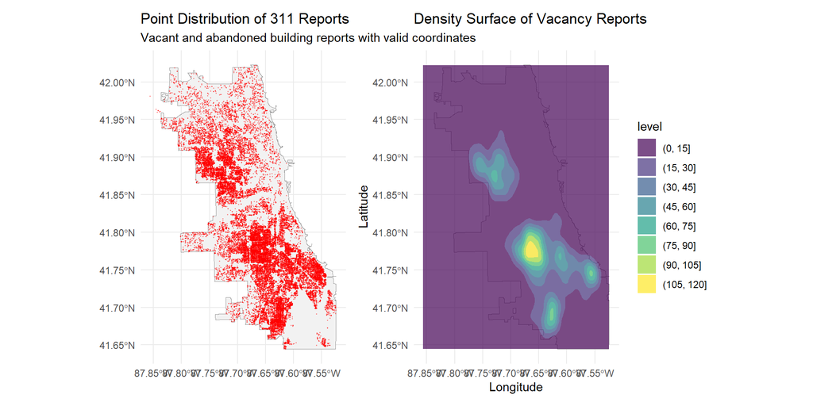

```r
# Create plotting versions in lon/lat so both maps display cleanly
boundary_plot <- st_transform(chicago_boundary, 4326)
vacant_plot   <- st_transform(vacant_sf, 4326)

vacant_coords <- st_coordinates(vacant_plot) |>
  as.data.frame()

map1 <- ggplot() +
  geom_sf(data = boundary_plot, fill = "gray95", color = "gray60", linewidth = 0.2) +
  geom_sf(data = vacant_plot, color = "red", alpha = 0.35, size = 0.15) +
  labs(
    title = "Point Distribution of 311 Reports",
    subtitle = "Vacant and abandoned building reports with valid coordinates"
  ) +
  theme_minimal()

map2 <- ggplot() +
  geom_sf(data = boundary_plot, fill = "gray95", color = "gray60", linewidth = 0.2) +
  geom_density_2d_filled(
    data = vacant_coords,
    aes(X, Y),
    alpha = 0.7,
    bins = 8
  ) +
  labs(
    title = "Density Surface of Vacancy Reports",
    x = "Longitude",
    y = "Latitude"
  ) +
  theme_minimal()

map1 + map2
```

**Interpretation of distribution**:

The two maps show that vacant and abandoned building reports are not evenly distributed across Chicago. A few community areas have noticeably higher numbers of reports than the rest of the city, especially in parts of the central South and Northwest sides. In contrast, many northern and eastern community areas have relatively low counts. his pattern suggests that vacant and abandoned building complaints are associated with uneven neighborhood conditions across Chicago.

## Part 2: Fishnet Grid Creation

In this step, I created a 500 by 500 fishnet grid and counted how many vacancy reports fell inside each grid cell. This is important because the fishnet gives me a consistent unit of analysis across the city, which makes it easier to compare places and build count models. After aggregation, I found that many grid cells had very low counts while a smaller number of cells had much higher counts.

### 1. Create a 500 by 500 fishnet

```r
# Create fishnet based on Chicago boundary
fishnet <- st_make_grid(
  chicago_boundary,
  cellsize = 500,
  square = TRUE
) |>
  st_as_sf() |>
  mutate(grid_id = row_number())

# Keep only cells that intersect Chicago
fishnet <- fishnet[chicago_boundary, ]
```

### 2. Aggregate 311 to grid cells

```r
vacant_grid_counts <- st_join(
  vacant_sf,
  fishnet,
  join = st_within,
  left = FALSE
) |>
  st_drop_geometry() |>
  count(grid_id, name = "report_count")

fishnet_counts <- fishnet |>
  left_join(vacant_grid_counts, by = "grid_id") |>
  mutate(report_count = replace_na(report_count, 0))
```

**Summarize report counts**:

```r
grid_summary <- tibble(
  metric = c(
    "Number of grid cells",
    "Grid cells with at least one report",
    "Maximum reports in a grid cell",
    "Mean reports per grid cell"
  ),
  value = c(
    nrow(fishnet_counts),
    sum(fishnet_counts$report_count > 0),
    max(fishnet_counts$report_count, na.rm = TRUE),
    round(mean(fishnet_counts$report_count, na.rm = TRUE), 2)
  )
)

kable(
  grid_summary,
  caption = "Summary Statistics of Vacant and Abandoned Building Reports by Fishnet Cell"
)
```

Summary Statistics of Vacant and Abandoned Building Reports by Fishnet Cell

| metric | value |
| --- | --- |
| Number of grid cells | 2458.00 |
| Grid cells with at least one report | 1916.00 |
| Maximum reports in a grid cell | 378.00 |
| Mean reports per grid cell | 26.47 |

### 3. Visualize distribution

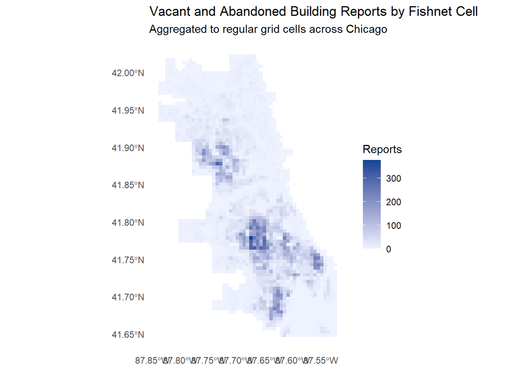

```r
ggplot(fishnet_counts) +
  geom_sf(aes(fill = report_count), color = NA) +
  scale_fill_gradient(
    low = "#eff3ff",
    high = "#084594"
  ) +
  labs(
    title = "Vacant and Abandoned Building Reports by Fishnet Cell",
    subtitle = "Aggregated to regular grid cells across Chicago",
    fill = "Reports"
  ) +
  theme_minimal() +
  theme(
    panel.grid.major = element_blank(),
    panel.grid.minor = element_blank()
  )
```

**Interpretation**:

This map shows the spatial distribution that is aggregated by fishnet cells. It shows the same pattern as the previous maps.